# schoolbuses - main

Gabriel Florit

This is one of many analysis pieces used to create [a story on Boston Public School buses tardiness](http://www.bostonglobe.com/metro/2015/06/20/boston-schools-contend-with-late-buses/sYiLTm5EJj6ZNbbXRYMryM/story.html).

Calculate various datasets.

This is a story about buses. Boston Public School buses. On any given day, hundreds of buses carry thousands of kids to school. Here’s September 4, the first day of classes.

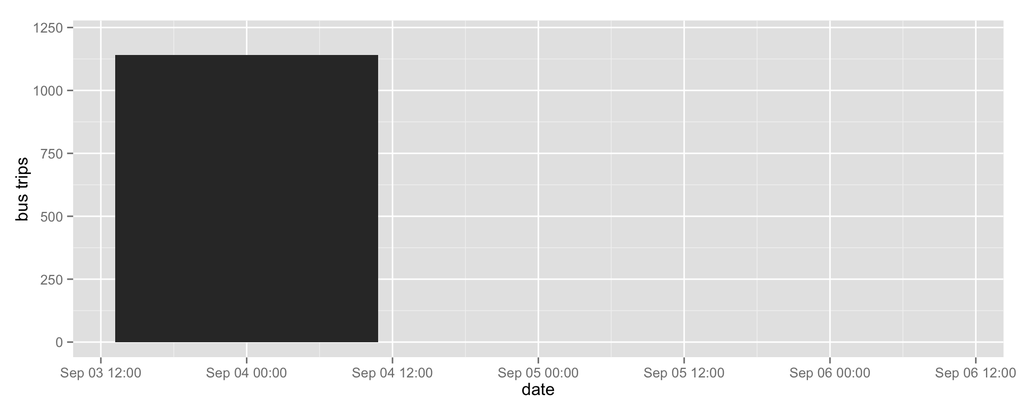

And here’s the rest of the year.

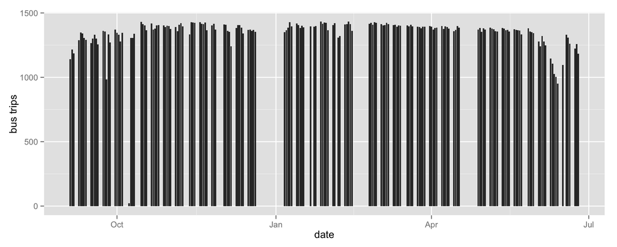

Over 14% of buses arrived late.

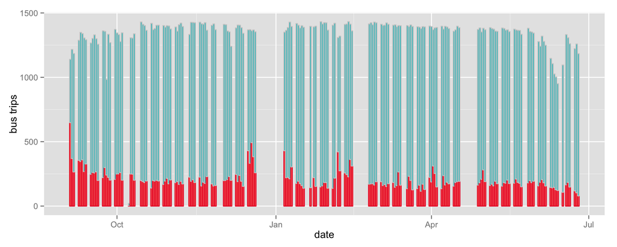

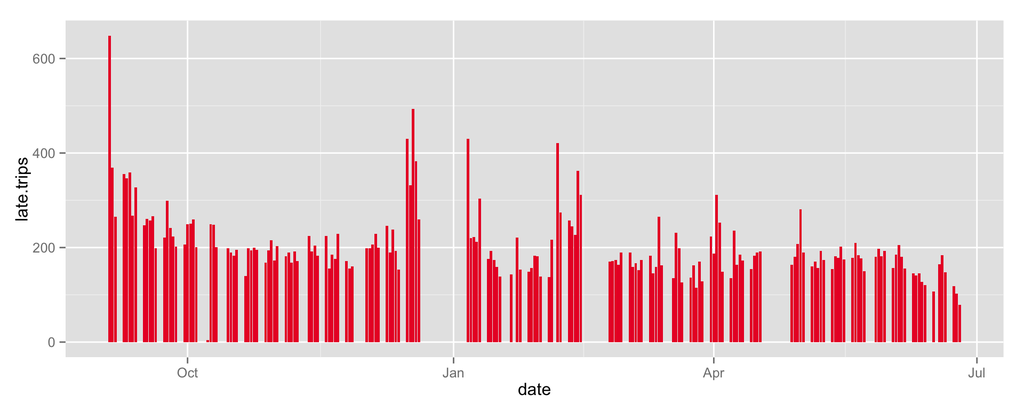

On the first day of school, 648 buses show up after the bell.

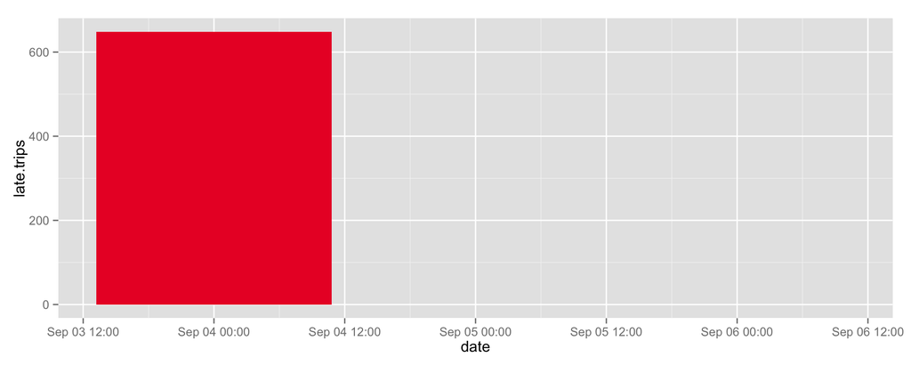

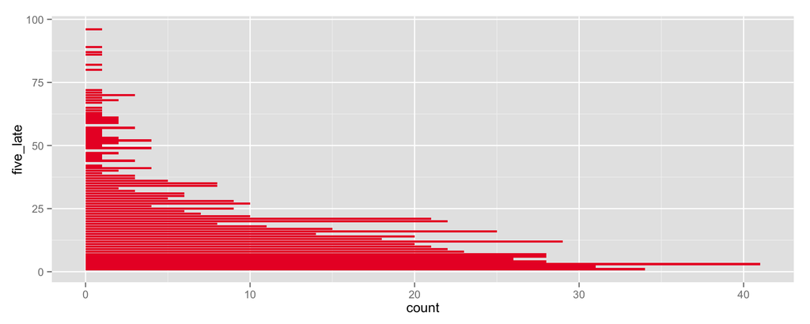

Over the school year, as drivers become familiar with their routes, tardiness decreases. But buses continue to arrive late.

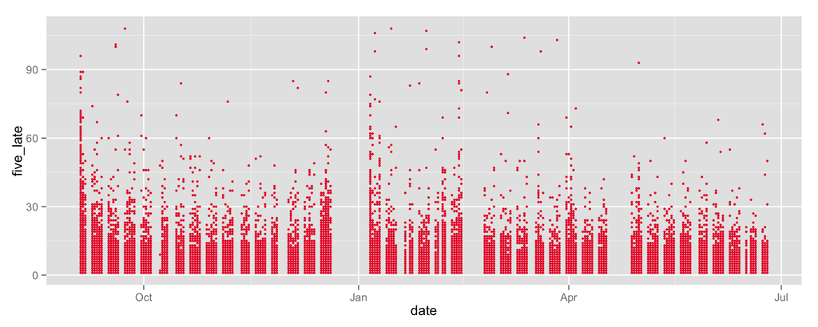

What about looking at the first week?

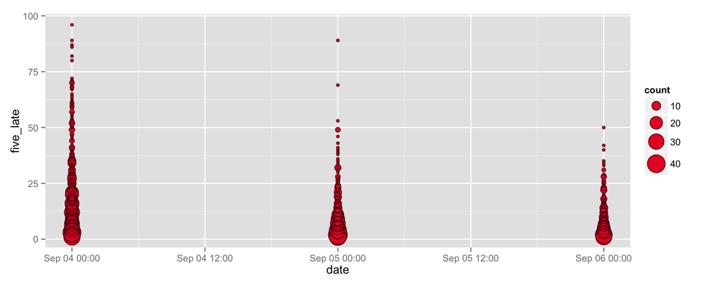

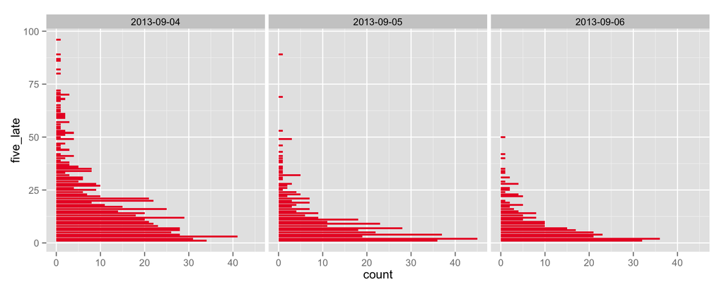

Are there weekly patterns? In other words, find the tardiness percentage for every day. Then do a histogram, facet by day of week.

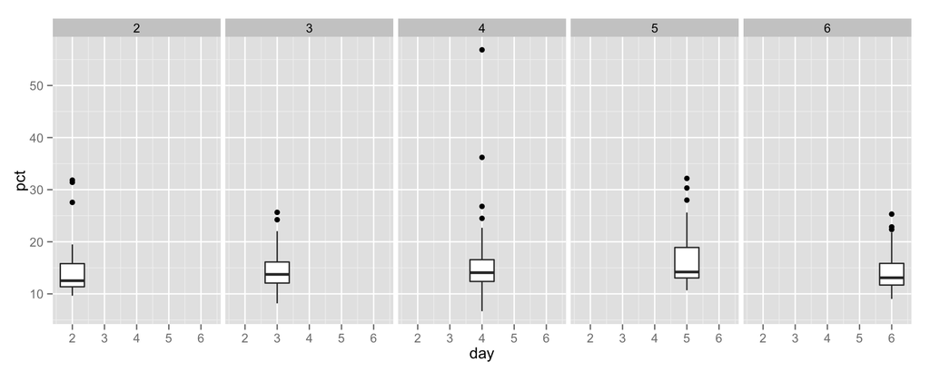

That doesn’t look useful. Let’s look at tardiness median per day.

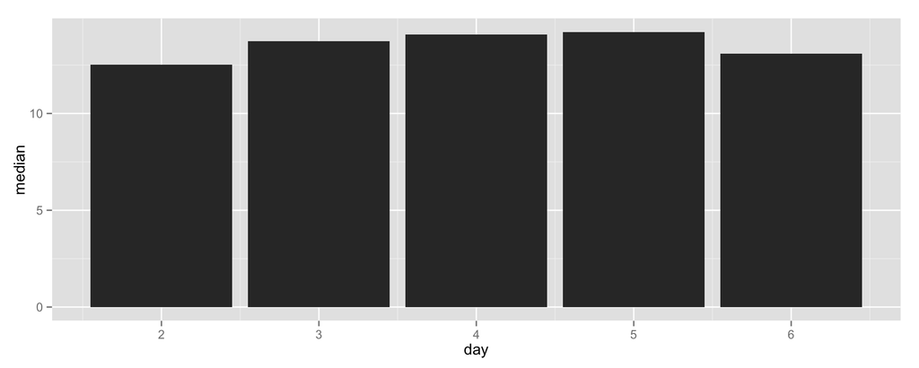